# A03c_G48129884

### a. Then run the following R commands. Please spend some time trying understand the code well.

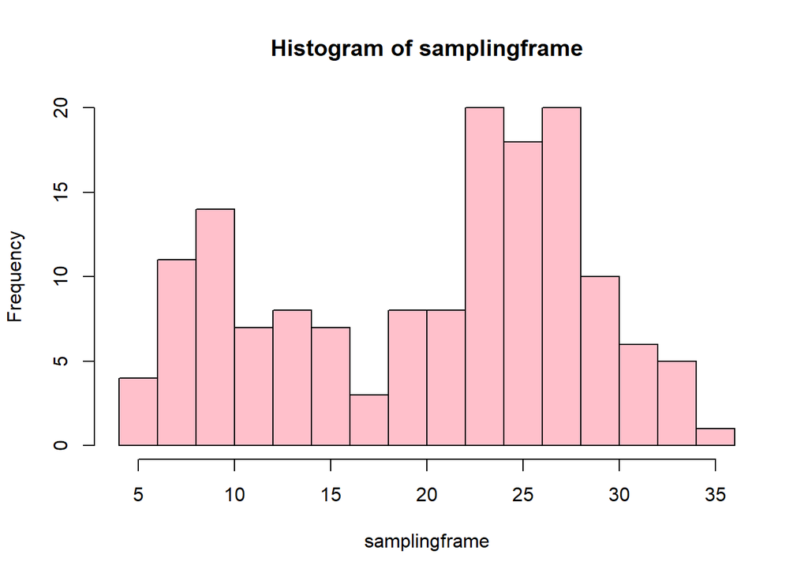

```r
rnorm2 <- function(n,mean,sd) { mean+sd*scale(rnorm(n)) }
set.seed(1239)
r1 <- rnorm2(100,25,4)
r2 <- rnorm2(50,10,3)
samplingframe <- c(r1,r2)
hist(samplingframe, breaks=20,col = "pink")
```

rnorm2 is a function that generate random variables from normal distribution with certain mean and stand deviation. Then get random seed(1239). After that, generate vector r1 with simple size =100, mean =25, sd =4 of normal distribution, so as r2, but with size =50, mean =10, sd =3 . Finally, get r1 r2 as a collection samplingframe and plot it as histogram. See this is the distribution and it is not normal distribution like.

### b. Draw 50 samples of size 15, and plot the sampling distribution of means as a histogram.

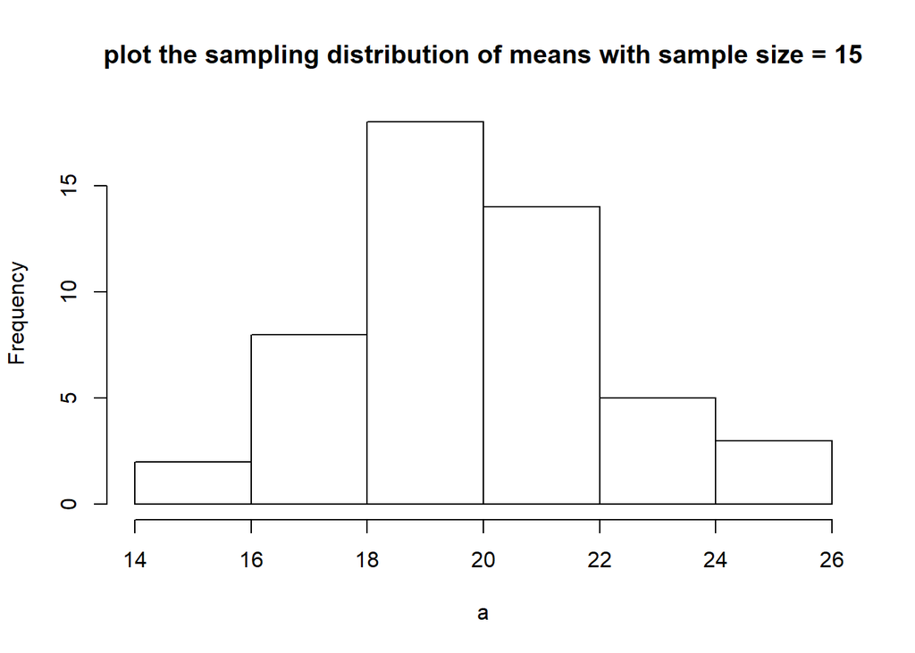

```r
set.seed(1239)
a=1:50
for(i in 1:50) a[i]=mean(sample(samplingframe,size = 15, replace = T))
hist(a, main = "plot the sampling distribution of means with sample size = 15")
```

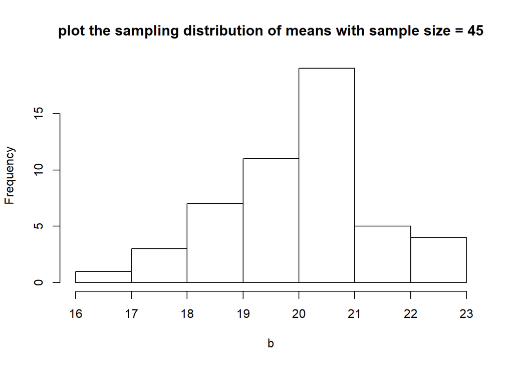

```r
set.seed(1239)
b =1:50
for(i in 1:50) b[i]=mean(sample(samplingframe,size = 45, replace = T))
hist(b, main = "plot the sampling distribution of means with sample size = 45")
```

###d. Make sure that the distributions in parts b and c are on the same plot. Explain the three histograms in terms of their differences and similarities.

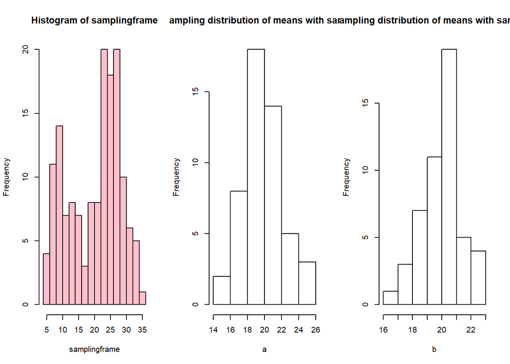

```r
op <- par(mfrow = c(1, 3))
hist(samplingframe, breaks=20,col = "pink")
f2=hist(a, main = "plot the sampling distribution of means with sample size = 15")
hist(b, main = "plot the sampling distribution of means with sample size = 45")
```

### e. Explain CLT in your own words. Restrict your response to less than 50 words.

sampling from one population with any distribution, the distribution of mean of sample will be more normal like as sample size grows larger.

### f. Does this exercise help you understand CLT? If so why? If not, why not? Restrict your response to less than 50 words.

yes. If we make the sample and sample size much large enough even infinite, we can find the distribution of mean will be very close to normal distribution.